# Data Visualization

### By: abdullah Elsayed

- 1. Introduction
- 2. Matplotlib

## 1. Introduction

Data visualization is the graphical representation of information and data. By using visual elements like charts, graphs, and maps, data visualization tools provide an accessible way to see and understand trends, outliers, and patterns in data.

In the world of Big Data, data visualization tools and technologies are essential to analyze massive amounts of information and make data-driven decision

#### Role of Data Visualization in data science

##### Python offers multiple great graphing libraries that come packed with lots of different features. No matter if you want to create interactive, live or highly customized plots python has an excellent library for you.

#### To get a little overview here are a few popular plotting libraries:

- [Matplotlib: low level, provides lots of freedom](https://matplotlib.org/)
- [Pandas Visualization:](https://pandas.pydata.org/pandas-docs/stable/user_guide/visualization.html) easy to use interface, built on Matplotlib
- [Seaborn:](https://seaborn.pydata.org/index.html) high-level interface, great default styles
- [ggplot:](https://ggplot2.tidyverse.org/) based on R’s ggplot2, uses [Grammar of Graphics](https://thatdatatho.com/grammar-of-graphics-ggplot2/)
- [Plotly:](https://plotly.com/python/getting-started/) can create interactive plots

## Matplotlib

##### To install Matplotlib pip and conda can be used.

pip install matplotlib or conda install matplotlib

##### It can be imported by typing:

```python
import matplotlib.pyplot as plt
```

## Plot Anatomy & Workflow

##### The basic steps to creating plots with matplotlib are:

1 Prepare Data 2Create Plot 3 Plot 4 Customized Plot 5 Save Plot 6 Show Plot

[figure not shown]

#### 1. Create Data

```python
## Prepare data
import numpy as np
x = np.linspace(1,100,10, dtype=np.int64)
y = np.power(x,1.1)
print(x)
print(y)
```

```
[  1  12  23  34  45  56  67  78  89 100]
[  1.          15.38506625  31.47028092  48.37564947  65.84666218
  83.75424532 102.01928676 120.58799186 139.42126129 158.48931925]
```

#### 2. Create plot(figure and axes)

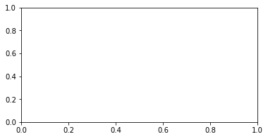

```python
## Create plot by add fig and axes

fig, ax = plt.subplots(figsize=(6,3))  ## 6 is width,  3 is height

plt.show()
```

- All plotting is done with respect to an Axes. In most cases, a subplot will fit your needs.
- A subplot is an axes on a grid system.

#### 3. plot data on figure

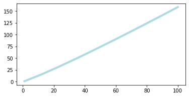

```python
## Create plot by add fig and axes
fig, ax = plt.subplots(figsize=(6,3))  ## 6 is width,  3 is height

## Plot the data
ax.plot(x, y, color= 'lightblue' , linewidth=4)

plt.show()
```

#### 4. Customize your plot and save it

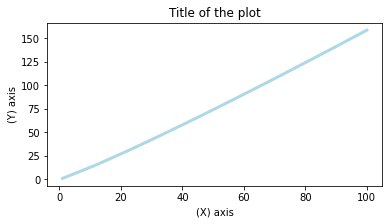

```python
## Create plot by add fig and axes
fig, ax = plt.subplots(figsize=(6,3))  ## 6 is width,  3 is height

## Plot the data
ax.plot(x, y, color= 'lightblue' , linewidth=3)

## cstomize plot
ax.set_title('Title of the plot') ## add title
ax.set_xlabel('(X) axis') ## add label to x axis
ax.set_ylabel('(Y) axis') ## add label to y axis

## Save plot
# plt.savefig("source/name of plot.extension")
plt.show()
```

## Line Chart

This type of chart is created by connecting a series of data points together with a solid line

When to use a Line Chart --> If you have continuous data that you would like to represent through a chart then a line chart is a good option

Usually these graphs show time series data but they can display other continuous variables like distance, for example how the level of a chemical varies with depth of soil.

In Matplotlib we can create a line chart by calling the plot method. We can also plot multiple columns in one graph, by looping through the columns we want and plotting each column on the same axis.

Plot number of employees per year

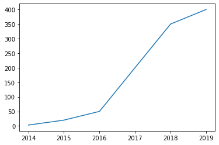

```python
## prepare data
emp_count = [3, 20, 50, 200, 350, 400]
year = [2014, 2015, 2016, 2017, 2018, 2019]

## create plot
fig,ax = plt.subplots()

## plot the data and customize the line
ax.plot(year, emp_count)


plt.show()
```

The same previous chart with some customizations

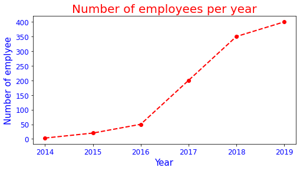

```python
## prepare data
emp_count = [3, 20, 50, 200, 350, 400]
year = [2014, 2015, 2016, 2017, 2018, 2019]

## create plot
fig,ax = plt.subplots(figsize=(8,4))  ## size of figure --> width 8 and height 4

## plot the data and customize the line
ax.plot(year, emp_count,
       marker='o', ## marker for each single point on the x-axis
       linestyle='--',
       linewidth=2,
       color='r')


## customize ur plots
ax.set_title("Number of employees per year", fontsize=20, color='r') ## add title for the chart
ax.set_xlabel("Year", fontsize=15, color='b')  ## add label for x-axis
ax.set_ylabel("Number of emplyee", fontsize=15, color='b')  ## add label for y-axis

plt.xticks(color='b', fontsize=12)  ## also u can use x_pos, bars
plt.yticks(color='b', fontsize=12)

plt.show()
```

##### Choose the style for ur charts

This [script](https://matplotlib.org/stable/gallery/style_sheets/style_sheets_reference.html) demonstrates the different available style sheets on a common set of example plots: scatter plot, image, bar graph, patches, line plot and histogram

```python
plt.style.use('seaborn-darkgrid')
```

##### Plot multiple lines in a single chart

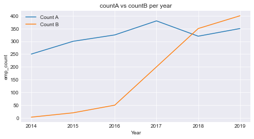

```python
## prepare data
emp_countA = [250, 300, 325, 380, 320, 350]
emp_countB = [3, 20, 50, 200, 350, 400]
year = [2014, 2015, 2016, 2017, 2018, 2019]

## create plot
fig, ax = plt.subplots(figsize=(8,4))

## plot data
ax.plot(year, emp_countA, label='Count A')
ax.plot(year, emp_countB, label='Count B')

ax.set(title='countA vs countB per year',
      xlabel='Year',
      ylabel='emp_count')

ax.legend() ## add legends with labels
plt.show()
```

##### Also we can plot all columns in dataframe using loop

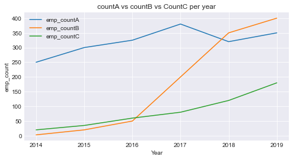

```python
import pandas as pd

## prepare data
emp_countA = [250, 300, 325, 380, 320, 350]
emp_countB = [3, 20, 50, 200, 350, 400]
emp_countC = [20, 35, 60, 80, 120, 180]
year = [2014, 2015, 2016, 2017, 2018, 2019]
df = {'Year':year,'emp_countA':emp_countA, 'emp_countB':emp_countB, 'emp_countC':emp_countC }
df = pd.DataFrame(df)


fig, ax = plt.subplots(figsize=(8,4))

for col in df.columns.drop(['Year']):
    ax.plot(year, df[col], label=df[col].name)

ax.set(title='countA vs countB vs CountC per year',
      xlabel='Year',
      ylabel='emp_count')

ax.legend(loc='upper left') ## add legends with labels
plt.show()
```

##### Plot columns on multiple charts

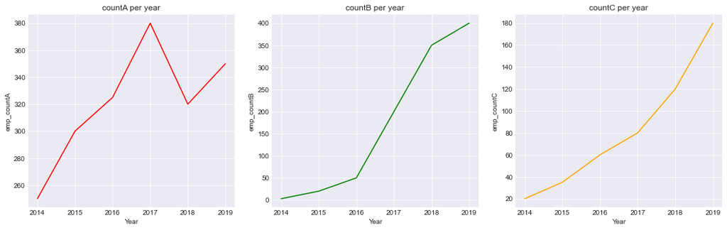

```python
## create plot
fig, ax = plt.subplots(nrows=1, ncols=3, figsize=(15,5))

## first chart
ax[0].plot(df['Year'], df['emp_countA'], color='red')
ax[0].set(title='countA per year',
      xlabel='Year',
      ylabel='emp_countA')

## second chart
ax[1].plot(df['Year'], df['emp_countB'], color='green')
ax[1].set(title='countB per year',
      xlabel='Year',
      ylabel='emp_countB')

## third chart
ax[2].plot(df['Year'], df['emp_countC'], color='orange')
ax[2].set(title='countC per year',
      xlabel='Year',
      ylabel='emp_countC')

plt.tight_layout(pad=2)
plt.show()
```

### Furthermore Reading:

- A Complete Guide to Line Charts: https://chartio.com/learn/charts/line-chart-complete-guide/
- Line Chart Tutorial : https://pythonbasics.org/matplotlib-line-chart/

## bar Chart

- A bar chart displays categorical data with rectangular bars whose length or height corresponds to the value of each data point.
- Bar charts can be visualized using vertical or horizontal bars.
- Bar charts are best used to compare a single category of data or several.
- Bar charts use volume to demonstrate differences between each bar. Because of this, bar charts should always start at zero. When bar charts do not start at zero, it risks users misjudging the difference between data values.

##### Prepare data

```python
df = pd.DataFrame.from_dict(
    {
        'year': [2016, 2017, 2018, 2019, 2020, 2021],
        'men': [200, 120, 310, 305, 325, 100],
        'women': [350, 325, 300, 200, 380, 355],
        'total': [550,445, 610, 506, 705, 455]
    }
)
print(df.head())
```

```
   year  men  women  total
0  2016  200    350    550
1  2017  120    325    445
2  2018  310    300    610
3  2019  305    200    506
4  2020  325    380    705
```

##### create first bar chart

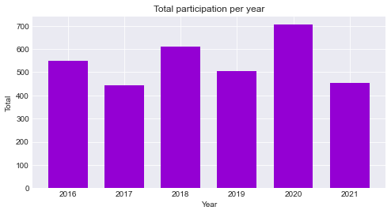

```python
## create plot using the year and the total
fig, ax= plt.subplots(figsize=(8,4))

## plot the data
ax.bar(df['year'], df['total'], color='darkviolet', width=0.7)


## cstomize the plot
ax.set(title='Total participation per year',
      xlabel='Year',
      ylabel='Total')
plt.show()
```

##### choose the bar colors based on the condition

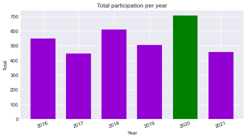

```python
## create plot using the year and the total
fig, ax= plt.subplots(figsize=(8,4))

## customize the color based on max column
colors = ['green' if (bar == max(df['total'])) else 'darkviolet' for bar in df['total']]

## plot the data
ax.bar(df['year'], df['total'], color=colors, width=0.7, align='center') ## align maybe 'edge'


## cstomize the plot
ax.set(title='Total participation per year',
      xlabel='Year',
      ylabel='Total')
plt.xticks(rotation=20) ## rotate x-axis
plt.show()
```

##### create a Stacked bar chart

- Using a Stacked bar chart is quite helpful when you want to compare two series of data

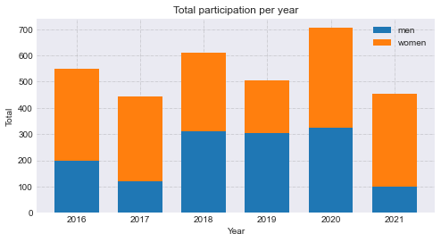

```python
## create plot using the year and the total
fig, ax= plt.subplots(figsize=(8,4))

## plot the data
ax.bar(x=df['year'], height=df['men'], label='men', width=0.7)
ax.bar(x=df['year'], height=df['women'], label='women', bottom=df['men'], width=0.7)

## add gridline
ax.grid(b = True, color ='grey',
        linestyle ='-.', linewidth = 0.5,
        alpha = 0.5)

## cstomize the plot
ax.set(title='Total participation per year',
      xlabel='Year',
      ylabel='Total')

## add gridline
ax.grid(b = True, color ='grey',
        linestyle ='-.', linewidth = 0.5,
        alpha = 0.5)


ax.legend()

plt.show()
```

## Scatter Chart

- A scatter plot is a data visualization that displays the values of two different variables as points. The data for each point is represented by its horizontal (x) and vertical (y) position on the visualization.
- Use a scatter plot to determine whether or not two variables have a relationship or correlation.
- If you have two variables that pair well together, plotting them on a scatter diagram is a great way to view their relationship and see if it’s a positive or negative correlation.
- Avoid a scatter plot when you have too large a set of data.

##### Prepare data

```python
x = range(50)
y = range(50) + np.random.randint(0,30,50)
```

##### plot first scatter plot

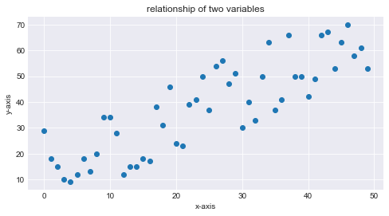

```python
## create plot
fig, ax=plt.subplots(figsize=(8,4))

## plot the data
ax.scatter(x,y)

## customization
ax.set(title='relationship of two variables',
      xlabel='x-axis',
      ylabel='y-axis')
plt.show()
```

.

##### change the color of the points to vary depending on the value of Y (or another variable of same size)

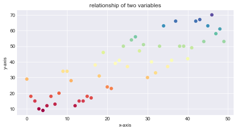

```python
## create plot
fig, ax=plt.subplots(figsize=(8,4))

## plot the data
ax.scatter(x,y,c=y, cmap='Spectral')

## customization
ax.set(title='relationship of two variables',
      xlabel='x-axis',
      ylabel='y-axis')
plt.show()
```

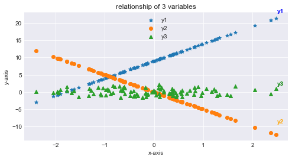

```python
## Prepare data
x=np.random.randn(100)
y1= x*5 +9
y2= -5*x
y3=np.random.randn(100)

## create plot
fig, ax = plt.subplots(figsize=(8,4))

# plot data
ax.scatter(x,y1, label='y1', marker= '*')
ax.scatter(x,y2, label='y2', marker= 'o')
ax.scatter(x,y3, label='y3', marker= '^')


## customization
ax.set(title='relationship of 3 variables',
      xlabel='x-axis',
      ylabel='y-axis')

plt.legend(loc='upper center')

# Annotate
plt.text(2.5, 23, "y1", horizontalalignment='left', size='medium', color='blue', weight='semibold')
plt.text(2.5, -9, "y2", horizontalalignment='left', size='medium', color='orange', weight='semibold')
plt.text(2.5, 2, "y3", horizontalalignment='left', size='medium', color='green', weight='semibold')

plt.show()
```

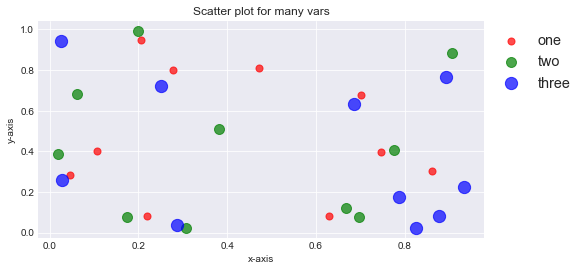

```python
## prepare data
x = np.random.random(10)
y = np.random.random(10)
x2 = np.random.random(10)
y2 = np.random.random(10)
x3 = np.random.random(10)
y3 = np.random.random(10)
## create plot
fig, ax=plt.subplots(figsize=(8,4))

## plot the data
ax.scatter(x,y,c='r', s=50, alpha=0.7, label='one')
ax.scatter(x2,y2,c='g', s=100, alpha=0.7, label='two')
ax.scatter(x3,y3,c='b', s=150, alpha=0.7, label='three')


## customization
ax.set(title='Scatter plot for many vars',
      xlabel='x-axis',
      ylabel='y-axis')
plt.legend(bbox_to_anchor=(1.0,1.0), fontsize='x-large')
plt.show()
```

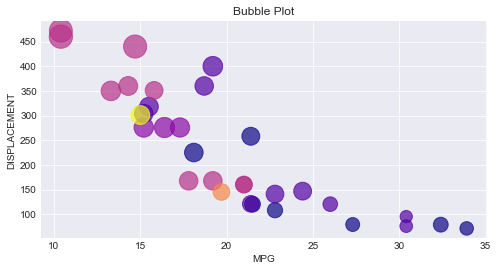

```python
# Bubble Plot
url = 'https://gist.githubusercontent.com/seankross/a412dfbd88b3db70b74b/raw/5f23f993cd87c283ce766e7ac6b329ee7cc2e1d1/mtcars.csv'
df=pd.read_csv(url)

## create plot
fig, ax=plt.subplots(figsize=(8,4))

## plot the data
ax.scatter(df['mpg'],df['disp'],alpha =0.7, s=100* df['wt'], c=df['carb'],cmap='plasma')

## customization
ax.set(title='Bubble Plot',
      xlabel='MPG',
      ylabel='DISPLACEMENT')
plt.show()
```

## PIE Chart

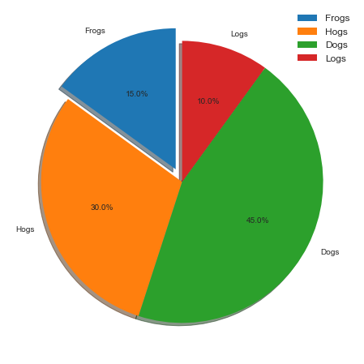

```python
## prepare data
labels = 'Frogs', 'Hogs', 'Dogs', 'Logs'
sizes = [15, 30, 45, 10]

## Create plt
fig, ax = plt.subplots(figsize=(8,8))

## plot data
ax.pie(sizes, labels=labels, shadow=True, explode=[0.1,0,0,0], autopct='%1.1f%%', startangle=90)

plt.legend(bbox_to_anchor=(1.0,1.0), fontsize='large')
plt.show()
```

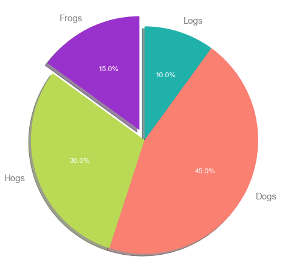

```python
## prepare data
labels = 'Frogs', 'Hogs', 'Dogs', 'Logs'
sizes = [15, 30, 45, 10]

## Create plot
fig, ax = plt.subplots(figsize=(8,8))

## add colors
colors = ['#9932cc','#bada55','#fa8072','#20b2aa']

## plot data
patches, texts, autotexts = ax.pie(sizes, labels=labels, colors=colors, shadow=True, explode=[0.1,0,0,0], autopct='%1.1f%%', startangle=90)

## customize annotation
for text in texts:
    text.set_color('grey')
    text.set_fontsize(15)
for text in autotexts:
    text.set_color('#fff')
    text.set_fontsize(12)

## plt.legend(fontsize='x-large')
ax.axis('equal')
plt.show()
```

## box plot

- Box plot gives statistical information about the distribution of numeric data divided into different groups. It is useful for detecting outliers within each group.

[figure not shown]

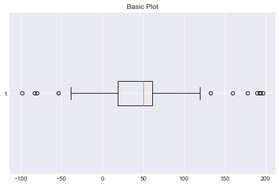

```python
# prepare data
np.random.seed(42)
spread = np.random.rand(50) * 100
center = np.ones(25) * 50
flier_high = np.random.rand(10) * 100 + 100
flier_low = np.random.rand(10) * -100
data = np.concatenate((spread, center, flier_high, flier_low))

## Create plot
fig, ax = plt.subplots(figsize=(8,5))

## plot data
ax.boxplot(data, showfliers=True, vert=False)

ax.set_title('Basic Plot')


plt.show()
```

## working with images

```python
import matplotlib.image as mpimg
```

[figure not shown]

```python
# reading the image
testImage = mpimg.imread('img/work_img.jpg')

# displaying the image
plt.imshow(testImage)
plt.show()
```

[output not shown]

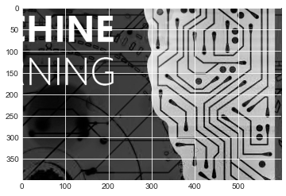

```python
# displaying the shape of the image
print(testImage.shape)

# modifying the shape of the image
modifiedImage = testImage[300:700, 300:900, 2]
plt.imshow(modifiedImage)
```

[output not shown]

Furthemore : https://www.machinelearningplus.com/plots/top-50-matplotlib-visualizations-the-master-plots-python/